```r
# dataset courtesy of user 'gregorut' via Kaggle:
# https://www.kaggle.com/gregorut/videogamesales

sales <- tibble::as_tibble(read.csv("vgsales.csv"))
head(sales)
```

```
## # A tibble: 6 x 11
##    Rank Name  Platform Year  Genre Publisher NA_Sales EU_Sales JP_Sales
##   <int> <chr> <chr>    <chr> <chr> <chr>        <dbl>    <dbl>    <dbl>
## 1     1 Wii ~ Wii      2006  Spor~ Nintendo      41.5    29.0      3.77
## 2     2 Supe~ NES      1985  Plat~ Nintendo      29.1     3.58     6.81
## 3     3 Mari~ Wii      2008  Raci~ Nintendo      15.8    12.9      3.79
## 4     4 Wii ~ Wii      2009  Spor~ Nintendo      15.8    11.0      3.28
## 5     5 Poke~ GB       1996  Role~ Nintendo      11.3     8.89    10.2
## 6     6 Tetr~ GB       1989  Puzz~ Nintendo      23.2     2.26     4.22
## # ... with 2 more variables: Other_Sales <dbl>, Global_Sales <dbl>
```

```r
colnames(sales)
```

```
##  [1] "Rank"         "Name"         "Platform"     "Year"         "Genre"
##  [6] "Publisher"    "NA_Sales"     "EU_Sales"     "JP_Sales"     "Other_Sales"
## [11] "Global_Sales"
```

```r
for(i in c(2, 3, 4, 5, 6)){
  sales[[i]] <- as.factor(sales[[i]])
}

# missing values
dim(sales)
```

```
## [1] 16598    11
```

```r
sales <- sales[!(is.na(sales$Year)), ]
dim(sales)
```

```
## [1] 16598    11
```

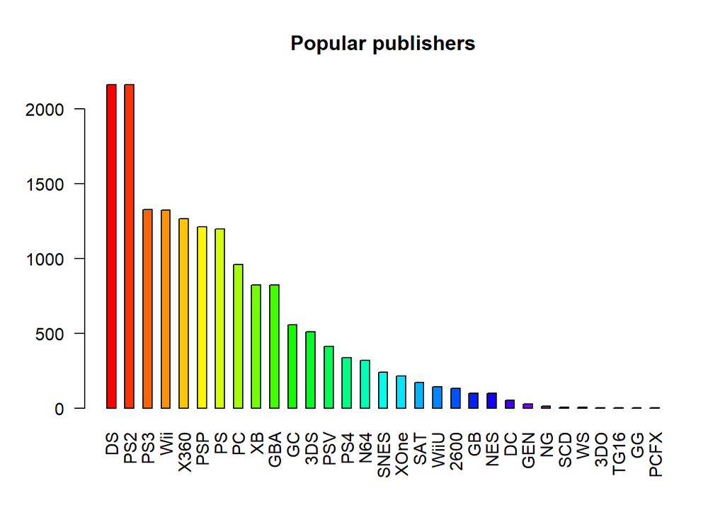

```r
# bar plot of counts by platform
par(mfrow=c(1, 1))
barplot(sort(table(sales$Platform), decreasing=T),
        col=rainbow(length(table(sales$Platform))),
        space=1,
        las=2,
        main="Popular publishers")
```

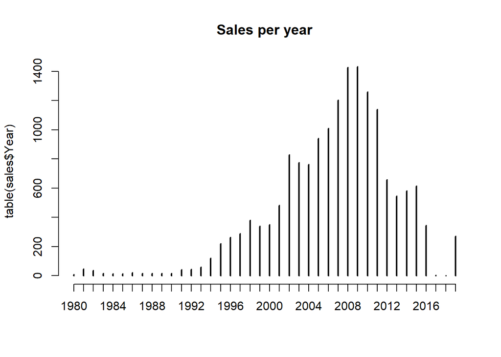

```r
# " year
plot(table(sales$Year), main="Sales per year")
```

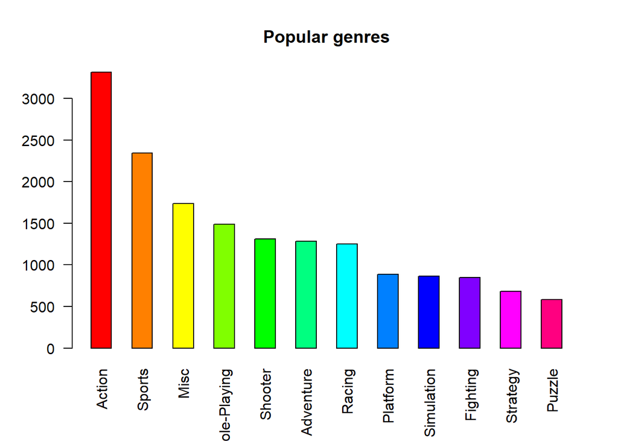

```r
# " genre
barplot(sort(table(sales$Genre), decreasing=T),
        col=rainbow(length(table(sales$Genre))),
        space=1,
        las=2,
        main="Popular genres")
```

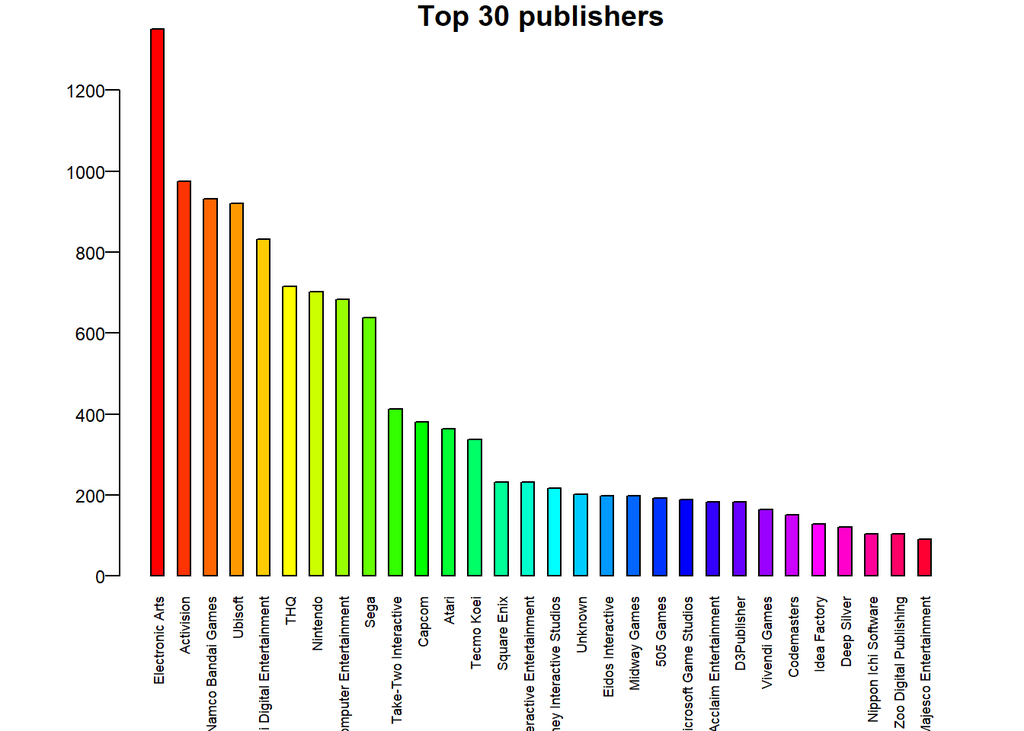

```r
# " publisher (top 30)
par(mar=c(5.1, 4.1, 1, 2.1), mgp=c(3, 0.5, 0))
barplot(sort(table(sales$Publisher), decreasing=T)[1:30],
        col=rainbow(30),
        space=1,
        las=2,
        cex.names=0.55,
        cex.axis=0.75,
        main="Top 30 publishers")
```

```r
# going to create new sales df sales_new; dropping legacy platforms (only a few obs)
# inspect them...
dim(sales)
```

```
## [1] 16598    11
```

```r
sort(table(sales$Platform)) # drop: GG, PCFX, TG16, 3DO, SCD, WS, NG, GEN, DC
```

```
##
##   GG PCFX TG16  3DO  SCD   WS   NG  GEN   DC   GB  NES 2600 WiiU  SAT XOne SNES
##    1    1    2    3    6    6   12   27   52   98   98  133  143  173  213  239
##  N64  PS4  PSV  3DS   GC  GBA   XB   PC   PS  PSP X360  Wii  PS3  PS2   DS
##  319  336  413  509  556  822  824  960 1196 1213 1265 1325 1329 2161 2163
```

```r
# remove, if not removed it will cause issues with estimating test error since the random selection of training indices may result in a model fit which omits Platforms which,s for example, only occur once
items <- c("GG", "PCFX", "TG16", "3DO", "SCD", "WS", "NG", "GEN", "DC")
for(item in items){
  sales <- sales[sales[, 3] != item, ]
}
```

# Creating a linear model

```r
set.seed(1)
train <- sample(dim(sales)[1], round(0.8*dim(sales)[1]))
lm_model <- lm(data=sales, Global_Sales ~ Platform + Genre + NA_Sales, subset=train)
summary(lm_model)
```

```
##
## Call:
## lm(formula = Global_Sales ~ Platform + Genre + NA_Sales, data = sales,
##     subset = train)
##
## Residuals:
##      Min       1Q   Median       3Q      Max
## -19.5426  -0.1157  -0.0445   0.0476  11.7852
##
## Coefficients:
##                    Estimate Std. Error t value Pr(>|t|)
## (Intercept)       -0.471308   0.051353  -9.178  < 2e-16 ***
## Platform3DS        0.651887   0.057030  11.431  < 2e-16 ***
## PlatformDS         0.524804   0.052565   9.984  < 2e-16 ***
## PlatformGB         1.019783   0.076938  13.255  < 2e-16 ***
## PlatformGBA        0.433211   0.054745   7.913 2.71e-15 ***
## PlatformGC         0.395830   0.056476   7.009 2.52e-12 ***
## PlatformN64        0.394515   0.060302   6.542 6.28e-11 ***
## PlatformNES        0.818459   0.075979  10.772  < 2e-16 ***
## PlatformPC         0.552767   0.054517  10.139  < 2e-16 ***
## PlatformPS         0.576985   0.053564  10.772  < 2e-16 ***
## PlatformPS2        0.571243   0.052512  10.878  < 2e-16 ***
## PlatformPS3        0.661965   0.053291  12.422  < 2e-16 ***
## PlatformPS4        0.795479   0.059503  13.369  < 2e-16 ***
## PlatformPSP        0.538660   0.053739  10.024  < 2e-16 ***
## PlatformPSV        0.530389   0.058564   9.057  < 2e-16 ***
## PlatformSAT        0.659959   0.067908   9.718  < 2e-16 ***
## PlatformSNES       0.820278   0.063634  12.890  < 2e-16 ***
## PlatformWii        0.490804   0.053371   9.196  < 2e-16 ***
## PlatformWiiU       0.560760   0.070216   7.986 1.51e-15 ***
## PlatformX360       0.405130   0.053385   7.589 3.44e-14 ***
## PlatformXB         0.377499   0.054755   6.894 5.66e-12 ***
## PlatformXOne       0.438647   0.063613   6.896 5.61e-12 ***
## GenreAdventure    -0.035393   0.019115  -1.852   0.0641 .
## GenreFighting     -0.005202   0.023003  -0.226   0.8211
## GenreMisc         -0.004555   0.017283  -0.264   0.7921
## GenrePlatform      0.009581   0.022263   0.430   0.6669
## GenrePuzzle       -0.018269   0.025944  -0.704   0.4813
## GenreRacing        0.038870   0.019473   1.996   0.0459 *
## GenreRole-Playing  0.142458   0.018165   7.842 4.76e-15 ***
## GenreShooter      -0.037803   0.018967  -1.993   0.0463 *
## GenreSimulation   -0.002182   0.022183  -0.098   0.9216
## GenreSports       -0.003326   0.015743  -0.211   0.8327
## GenreStrategy     -0.005082   0.024539  -0.207   0.8359
## NA_Sales           1.765439   0.006186 285.403  < 2e-16 ***
## ---
## Signif. codes:  0 '***' 0.001 '**' 0.01 '*' 0.05 '.' 0.1 ' ' 1
##
## Residual standard error: 0.5122 on 13156 degrees of freedom
## Multiple R-squared:  0.8691, Adjusted R-squared:  0.8688
## F-statistic:  2647 on 33 and 13156 DF,  p-value: < 2.2e-16
```

From the above model summary, it is worth noting the highly significant p value of RPG’s (Role-Playing Games).

# Linear model assumptions

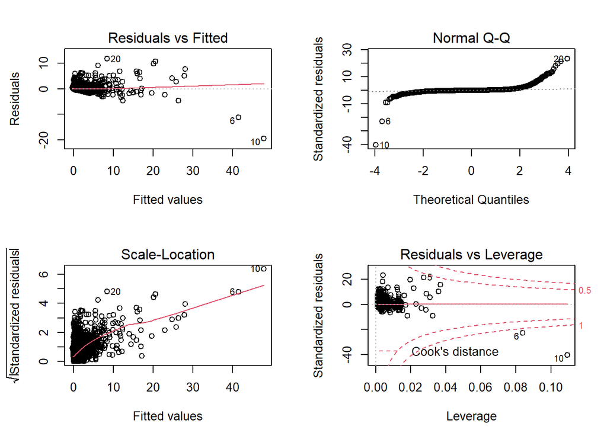

```r
# diagnostic plots
par(mar=c(4.7, 4.5, 3.4, 2.2), mfrow=c(2, 2), mgp=c(3, 1, 0))
plot(lm_model)
```

**1) Residuals vs Fitted:**  
No discernable evidence of non-linearity. It appears that a linear model captures the model sufficiently.

**2) Normal Q-Q:**  
This plot shows a ‘heavy-tailed’ distribution. Most notability at lower theoretical quantile values. It can be seen that the residuals deviate significantly at higher theoretical quantile values. This could be explained by the unpredictability of extremely high or unexpectedly low sales of some games.

**3) Scale-Location:**  
There is convincing evidence of a non-random spread and therefore heteroscedasticity. I think this is to be expected due to the nature of the data being analysed. Unfortunately this violates an assumption of OLS regression to the degree of heteroscedasticity present.

Current R-squared:

```r
summary(lm_model)$r.squared
```

```
## [1] 0.8691054
```

New R-squared:

```r
sales <- sales[-c(6, 10), ]
lm_model <- lm(data=sales, Global_Sales ~ Platform + Genre + NA_Sales, subset=train)
summary(lm_model)$r.squared
```

```
## [1] 0.8887784
```

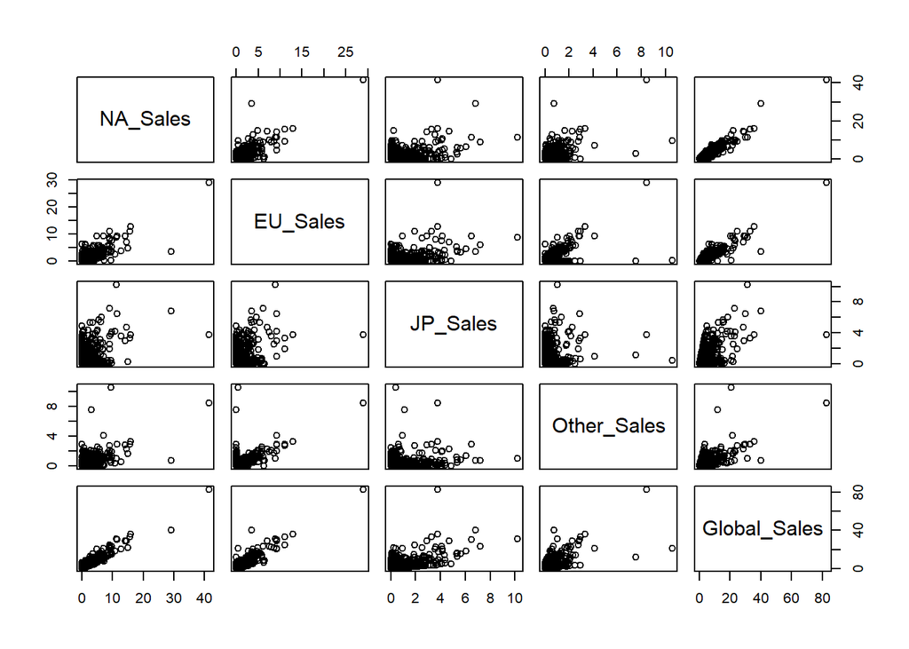

```r
# Check linearity, excluding categorical variables
sales_small <- sales[, -which(names(sales) %in% c("Rank", "Name", "Year", "Platform", "Genre", "Publisher"))]
pairs(sales_small)
```

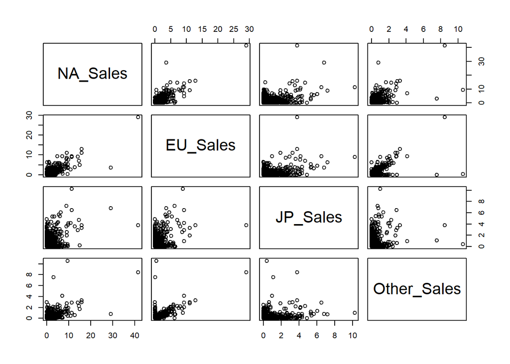

```r
# Check collinearity
sales_small <- sales[, -which(names(sales) %in% c("Rank", "Name", "Year", "Platform", "Genre", "Publisher", "Global_Sales"))]
pairs(sales_small)
```

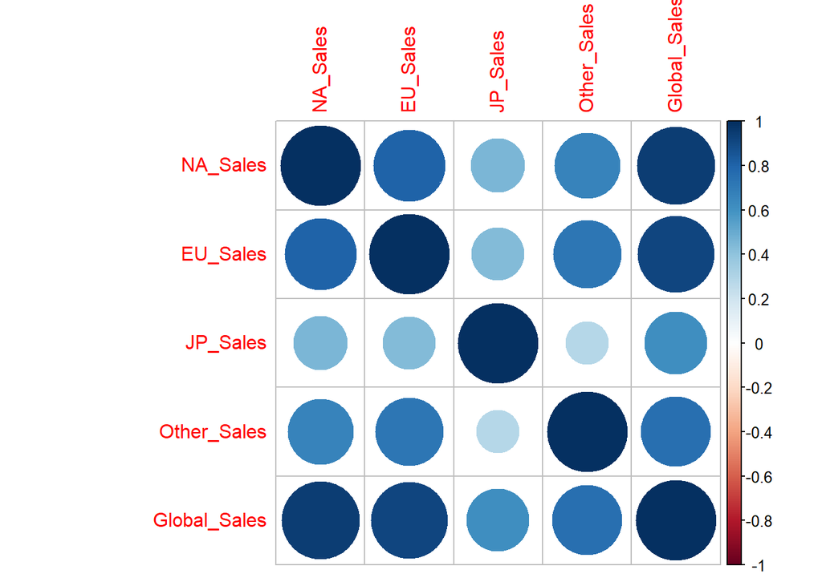

```r
# Pearson correlation matrix

library(corrplot)
correlations <- cor(sales[, 7:11])
corrplot(correlations, method="circle")
```

# Estimating test error

```r
# 1) Validation set
test_set <- subset(sales[-train, ], select=c(Platform, Genre, NA_Sales))
dim(test_set)
```

```
## [1] 3298    3
```

```r
sale_preds_test_set <- c()
for(i in 1:nrow(test_set)){
  temp_row <- test_set[i, ]
  pred <- predict(lm_model, newdata=temp_row)
  sale_preds_test_set <- c(sale_preds_test_set, pred)
}

predictions <- data.frame(Predicted=sale_preds_test_set,
                          Actual=rep(NA, length(sale_preds_test_set)))
actual_test_set_sales <- subset(sales[-train, ], select=c(Global_Sales))
predictions[, 2] <- actual_test_set_sales

vs_mse <- mean((sales$Global_Sales - predict(lm_model, sales))[-train]^2)
test_estimates <- data.frame(VSA=vs_mse)
```

```r
# 2) Leave-one-out cross-validation
library(boot)

glm_fit <- glm(Global_Sales ~ Platform + Genre + NA_Sales, data=sales)
coef(glm_fit)
```

```
##       (Intercept)       Platform3DS        PlatformDS        PlatformGB
##      -0.543140248       0.718678671       0.574181088       1.075898113
##       PlatformGBA        PlatformGC       PlatformN64       PlatformNES
##       0.497730865       0.450665598       0.408477420       0.917264537
##        PlatformPC        PlatformPS       PlatformPS2       PlatformPS3
##       0.618586625       0.617085636       0.608756337       0.702208917
##       PlatformPS4       PlatformPSP       PlatformPSV       PlatformSAT
##       0.815537323       0.602198368       0.597918705       0.725465741
##      PlatformSNES       PlatformWii      PlatformWiiU      PlatformX360
##       0.876408923       0.521814795       0.613879272       0.421699464
##        PlatformXB      PlatformXOne    GenreAdventure     GenreFighting
##       0.431959189       0.468208889      -0.020371423      -0.010582701
##         GenreMisc     GenrePlatform       GenrePuzzle       GenreRacing
##      -0.006413026      -0.041232215       0.001285357       0.032053371
## GenreRole-Playing      GenreShooter   GenreSimulation       GenreSports
##       0.134098760      -0.038523229       0.013576959      -0.003385929
##     GenreStrategy          NA_Sales
##       0.006482942       1.882206057
```

```r
cv_err <- cv.glm(sales, glm_fit)
cv_err$delta
```

```
## [1] 0.2298126 0.2298125
```

```r
cv_te <- c(cv_err$delta[1])
test_estimates <- cbind(test_estimates, cv_te)
```

```r
# 3) K-fold cross-validation
k_cv_err <- cv.glm(sales, glm_fit, K=10)
k_cv_err$delta
```

```
## [1] 0.2305986 0.2302456
```

```r
k_cv_te <- c(k_cv_err$delta[1])
test_estimates <- cbind(test_estimates, k_cv_te)

# Resulting test error estimates using each approach
test_estimates
```

```
##         VSA     cv_te   k_cv_te
## 1 0.2836757 0.2298126 0.2305986
```

# Visualising predicted vs actual

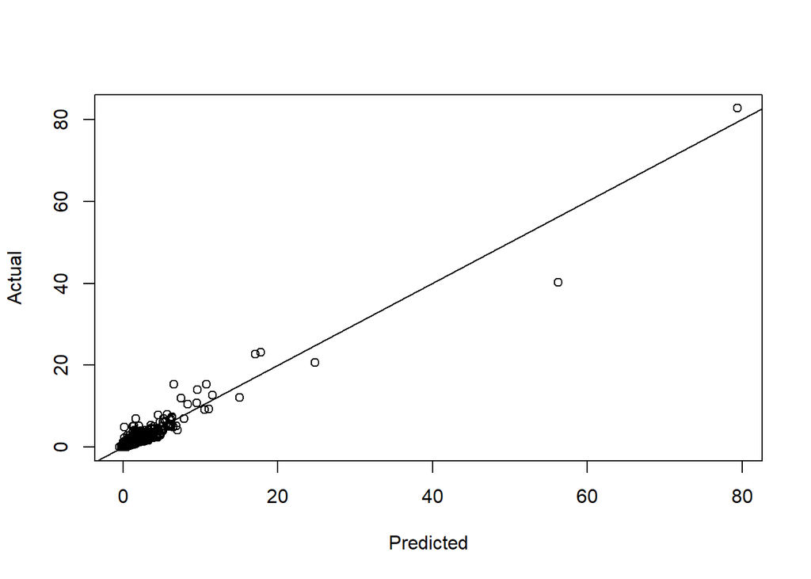

```r
plot(predictions$Predicted, predictions$Actual, xlab="Predicted", ylab="Actual")
abline(a=0, b=1)
```

# Concluding remarks

Overall this project was intended to test out the linear regression workflow in R based on my study of the textbook ‘Introduction to Statistical Learning’. While model accuracy was high and performed well on the test set, it requires more feature engineering to be robust - the obvious correlation between regional and global sales is a weak point, however, this project is not intended for model deployment and was just a fun exercise for myself. Ideally, after extensive feature engineering, the fit accuracy could be similar without using regional sales as a predictor.